# Bayesian data analysis & cognitive modeling

\[ \definecolor{firebrick}{RGB}{178,34,34} \newcommand{\red}[1]{{\color{firebrick}{#1}}} \] \[ \definecolor{mygray}{RGB}{178,34,34} \newcommand{\mygray}[1]{{\color{mygray}{#1}}} \] \[ \newcommand{\set}[1]{\{#1\}} \] \[ \newcommand{\tuple}[1]{\langle#1\rangle} \] \[\newcommand{\States}{{T}}\] \[\newcommand{\state}{{t}}\] \[\newcommand{\pow}[1]{{\mathcal{P}(#1)}}\]

## overview

- generalized linear model (GLM)
  - types of variables
    - metric, nominal, ordinal, count
- linear model
  - ordinary least squares regresssion
  - maximum likelihood regression
  - Bayesian approaches
- generalization to simplest \(t\)-test scenario

## generalized linear model

## probabilistic models

standard notion

model = likelihood function \(P(D \mid \theta)\)

Bayesian

model = likelihood \(P(D \mid \theta)\) + prior \(P(\theta)\)

approaches to modeling

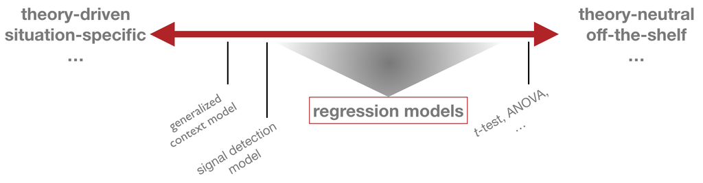

## generalized linear model

terminology

- \(y\) predicted variable, data, observation, …
- \(X\) predictor variables for \(y\), explanatory variables, …

blueprint of a GLM

\[ \begin{align*} \eta & = \text{linear_combination}(X) \\ \mu & = \text{link_fun}( \ \eta, \theta_{\text{LF}} \ ) \\ y & \sim \text{lh_fun}( \ \mu, \ \theta_{\text{LH}} \ ) \end{align*} \]

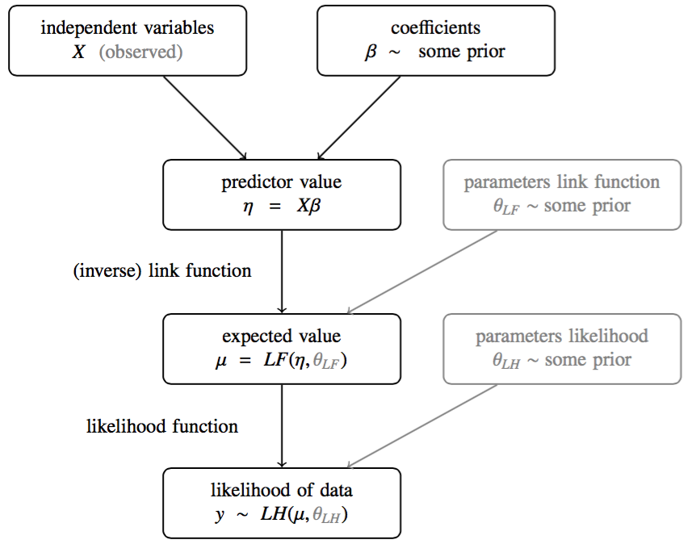

## types of variables

| type | examples |
| --- | --- |
| metric | speed of a car, reading time, average time spent cooking p.d., … |
| binary | coin flip, truth-value judgement, experience with R, … |
| nominal | gender, political party, favorite philosopher, … |
| ordinal | level of education, rating scale judgement, … |
| count | number of cars passing under bridge in 1h, … |

## common link & likelihood function

| type of \(y\) | (inverse) link function | likelihood function |
| --- | --- | --- |
| metric | \(\mu = \eta\) | \(y \sim \text{Normal}(\mu, \sigma)\) |
| binary | \(\mu = \text{logistic}(\eta, \theta, \gamma) = (1 + \exp(-\gamma (\eta - \theta)))^{-1}\) | \(y \sim \text{Binomial}(\mu)\) |
| nominal | \(\mu_k = \text{soft-max}(\eta_k, \lambda) \propto \exp(\lambda \eta_k)\) | \(y \sim \text{Multinomial}({\mu})\) |
| ordinal | \(\mu_k = \text{threshold-Phi}(\eta_k, \sigma, {\delta})\) | \(y \sim \text{Multinomial}({\mu})\) |
| count | \(\mu = \exp(\eta)\) | \(y \sim \text{Poisson}(\mu)\) |

## linear regression

## muder rate data set

```r
murder_data = readr::read_csv('../data/06_murder_rates.csv') %>%
  rename(murder_rate = annual_murder_rate_per_million_inhabitants,
         low_income = percentage_low_income,
         unemployment = percentage_unemployment) %>%
  select(murder_rate, low_income, unemployment,population)
murder_data %>% head
```

```
## # A tibble: 6 x 4
##   murder_rate low_income unemployment population
##         <dbl>      <dbl>        <dbl>      <int>
## 1        11.2       16.5          6.2     587000
## 2        13.4       20.5          6.4     643000
## 3        40.7       26.3          9.3     635000
## 4         5.3       16.5          5.3     692000
## 5        24.8       19.2          7.3    1248000
## 6        12.7       16.5          5.9     643000
```

## visualize data

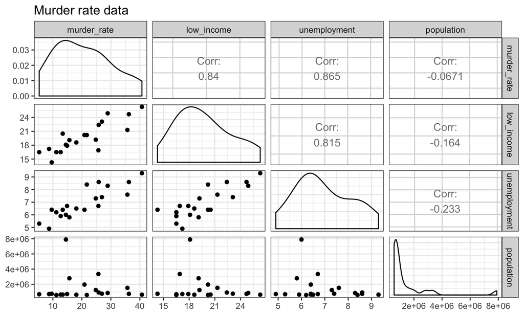

```r
GGally::ggpairs(murder_data,
                title = "Murder rate data")
```

## zooming in

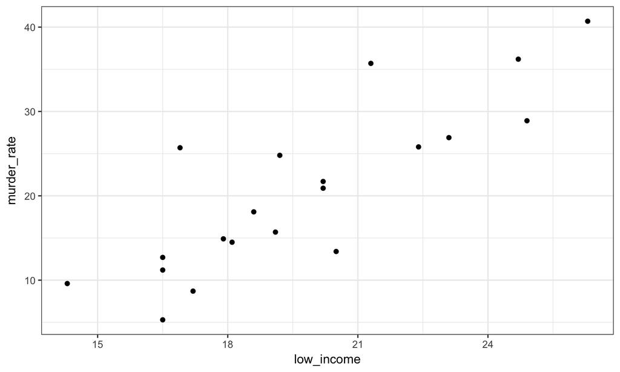

```r
murder_sub = select(murder_data, murder_rate, low_income)
rate_income_plot = ggplot(murder_sub,
    aes(x = low_income, y = murder_rate)) + geom_point()
rate_income_plot
```

## linear regression

given

- predicted variable \(y\): murder rates

  metric
- predictor variable \(x\): percentage low income

  metric

question

wich linear function –in terms of intercept \(\beta_0\) and slope \(\beta_1\)– approximates the data best?

\[ y_{\text{pred}} = \beta_0 + \beta_1 x \]

## ordinary linear regression

"geometric" approach

find \(\beta_0\) and \(\beta_1\) that minimize the squared error between predicted \(y_\text{pred}\) and observed \(y\)

```r
mse = function(y, x, beta_0, beta_1) {
  yPred = beta_0 + x * beta_1
  (y-yPred)^2 %>% mean
}
fit_mse = optim(par = c(0, 1),
  fn = function(par) with(murder_data,
    mse(murder_rate,low_income,
        par[1], par[2])))
fit_mse$par
```

```
## [1] -29.905188   2.559588
```

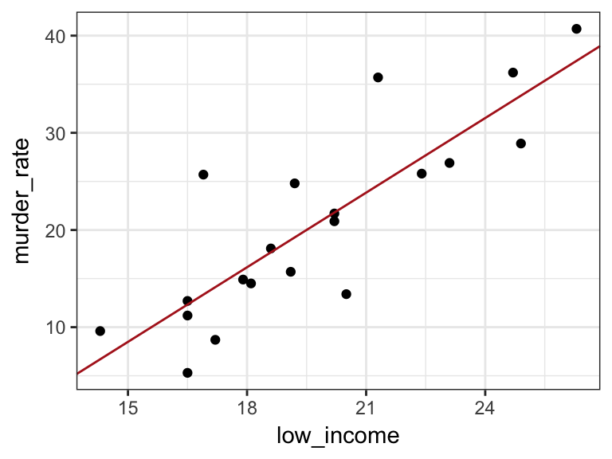

## linear regression: MLE

maximum likelihood approach

find \(\beta_0\) and \(\beta_1\) and \(\sigma\) that maximize the likelihood of observed \(y\):

\[ \begin{align*} y_{\text{pred}} & = \beta_0 + \beta_1 x & \ \ \ \ \ \ \ \ \ \ \ \ \ \ y & \sim \mathcal{N}(\mu = y_{\text{pred}}, \sigma) \end{align*} \]

```r
nll = function(y, x, beta_0, beta_1, sd) {
  if (sd <= 0) {return( Inf )}
  yPred = beta_0 + x * beta_1
  nll = -dnorm(y, mean=yPred, sd=sd, log = T)
  sum(nll)
}
fit_lh = optim(par = c(0, 1, 1),
  fn = function(par) with(murder_data,
    nll(murder_rate, low_income,
        par[1], par[2], par[3])))
fit_lh$par
```

```
## [1] -29.901445   2.559601   5.234126
```

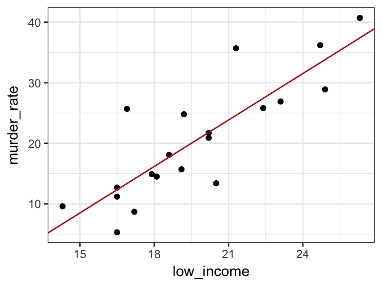

## compare homebrew to the "real thing"

```r
fit_lm = lm(formula = murder_rate ~ low_income, data = murder_data)
fit_glm = glm(formula = murder_rate ~ low_income, data = murder_data)

tibble(parameter = c("beta_0", "beta_1"),
       manual_mse = fit_mse$par,
       manual_lh = fit_lh$par[1:2],
       lm = fit_lm %>% coefficients,
       glm = fit_glm %>% coefficients) %>% show
```

```
## # A tibble: 2 x 5
##   parameter manual_mse  manual_lh        lm       glm
##       <chr>      <dbl>      <dbl>     <dbl>     <dbl>
## 1    beta_0 -29.905188 -29.901445 -29.90116 -29.90116
## 2    beta_1   2.559588   2.559601   2.55939   2.55939
```

## linear regression: a Bayesian approach

Bayes: likelihood + prior

inspect posterior distribution over \(\beta_0\), \(\beta_1\) and \(\sigma_{\text{err}}\) given the data \(y\) and the model:

\[ \begin{align*} y_{\text{pred}} & = \beta_0 + \beta_1 x & \ \ \ \ \ \ \ \ \ \ \ \ \ \ y & \sim \mathcal{N}(\mu = y_{\text{pred}}, \sigma_{err}) \\ \beta_i & \sim \mathcal{N}(0, \sigma_{\beta}) & \ \ \ \ \ \ \ \ \ \ \ \ \ \ \frac{1}{\sigma_{err}^2} & \sim \text{Gamma}(0.1,0.1) \end{align*} \]

```r
model{
  sigma_e = 1/sqrt(tau_e)
  tau_e ~ dgamma(0.1,0.1)
  b0 ~ dnorm(0, 1/10000000)
  b1 ~ dnorm(0, 1/10000000)
  for (i in 1:k){
    yPred[i] = b0 + b1 * x[i]
    y[i] ~ dnorm(yPred[i], tau_e)
  }
}
```

## linear regression: a Bayesian approach

```
## # A tibble: 2 x 4
##   Parameter     HDI_lo       mean     HDI_hi
##      <fctr>      <dbl>      <dbl>      <dbl>
## 1        b0 -45.434242 -29.124843 -12.157119
## 2        b1   1.711819   2.520637   3.377466
```

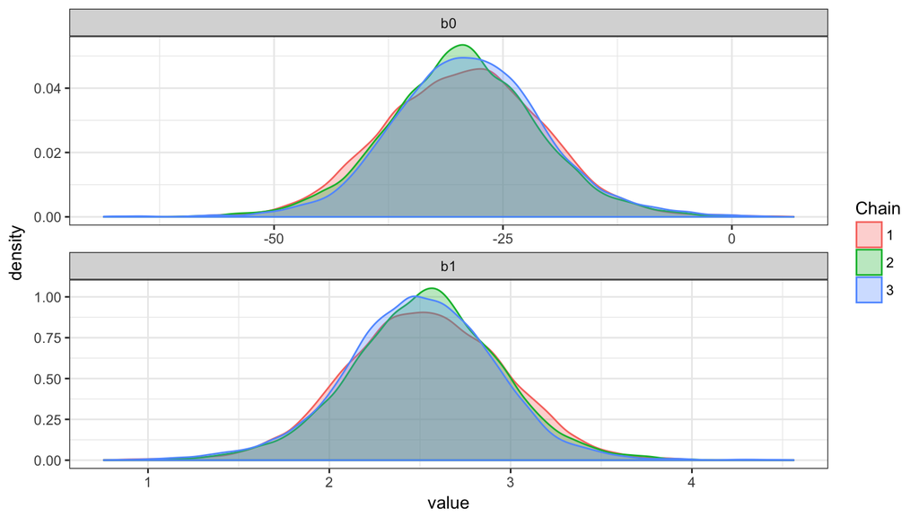

## inference with regression models

## inference with regression models

parameter estimation

- is coefficient \(\beta_i\) significantly/credibly different from, e.g., 0?

model comparison

- compare model with \(\beta_i\) fixed to model with \(\beta_i\) free

prediction/model criticism

- predict future data from model
- could model be a likely generating model of the observed data?

## significance of point-estimates of coefficients

```r
fit_glm = glm(formula = murder_rate ~ low_income, data = murder_data)
fit_glm %>% summary
```

```
##
## Call:
## glm(formula = murder_rate ~ low_income, data = murder_data)
##
## Deviance Residuals:
##     Min       1Q   Median       3Q      Max
## -9.1663  -2.5613  -0.9552   2.8887  12.3475
##
## Coefficients:
##             Estimate Std. Error t value Pr(>|t|)
## (Intercept)  -29.901      7.789  -3.839   0.0012 **
## low_income     2.559      0.390   6.562 3.64e-06 ***
## ---
## Signif. codes:  0 '***' 0.001 '**' 0.01 '*' 0.05 '.' 0.1 ' ' 1
##
## (Dispersion parameter for gaussian family taken to be 30.38125)
##
##     Null deviance: 1855.20  on 19  degrees of freedom
## Residual deviance:  546.86  on 18  degrees of freedom
## AIC: 128.93
##
## Number of Fisher Scoring iterations: 2
```

## credible intervals for posteriors over coefficients

```r
ggmcmc::ggs(codaSamples) %>%
  group_by(Parameter) %>%
  summarize(HDI_lo = coda::HPDinterval(as.mcmc(value))[1],
          mean = mean(value),
          HDI_hi = coda::HPDinterval(as.mcmc(value))[2])  %>%
  show
```

```
## # A tibble: 2 x 4
##   Parameter     HDI_lo       mean     HDI_hi
##      <fctr>      <dbl>      <dbl>      <dbl>
## 1        b0 -45.434242 -29.124843 -12.157119
## 2        b1   1.711819   2.520637   3.377466
```

## model comparison

frequentist

```r
fit_glm_simple = glm(formula = murder_rate ~ 1, data = murder_data)
AIC(fit_glm_simple, fit_glm)
```

```
##                df      AIC
## fit_glm_simple  2 151.3579
## fit_glm         3 128.9268
```

Bayesian

```r
# package does not 'like' tibbles
BayesFactor::regressionBF(formula = murder_rate ~ low_income,
            data = as.data.frame(murder_sub))
```

```
## Bayes factor analysis
## --------------
## [1] low_income : 3429.181 ±0.01%
##
## Against denominator:
##   Intercept only
## ---
## Bayes factor type: BFlinearModel, JZS
```

## \(t\)-test scenario

## IQ data

```r
iq_data = readr::read_csv('../data/07_Kruschke_TwoGroupIQ.csv')
summary(iq_data)
```

```
##      Score           Group
##  Min.   : 50.00   Length:120
##  1st Qu.: 92.75   Class :character
##  Median :102.00   Mode  :character
##  Mean   :104.13
##  3rd Qu.:112.00
##  Max.   :208.00
```

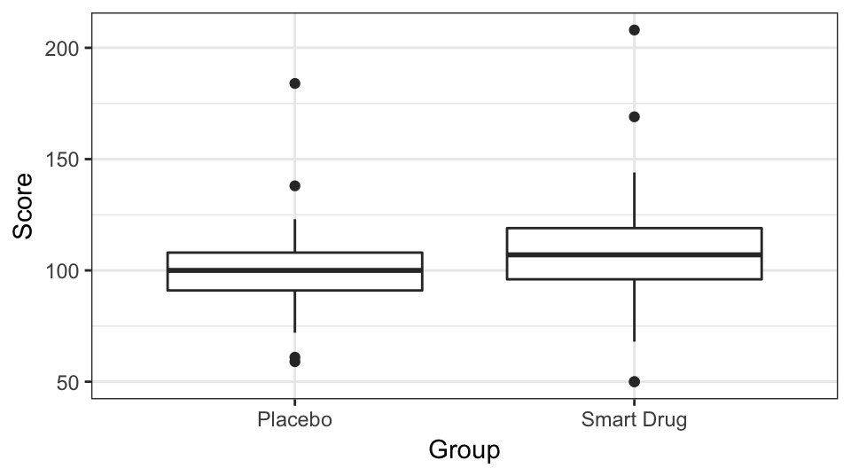

possible research questions?

1. is average IQ-score higher than 100 in treatment group?
2. is average IQ-score higher in treatment group than in control? ( next time)

from Kruschke (2015, Chapter 16)

## Case 1: IQ-score higher than 100 in treatment group?

Bayesian GLM:

inspect posterior distribution over \(\beta_0\) and \(\sigma_{\text{err}}\) given the data \(y\) and the model:

\[ \begin{align*} y_{\text{pred}} & = \beta_0 & \ \ \ \ \ \ \ \ \ \ \ \ \ \ y & \sim \mathcal{N}(\mu = y_{\text{pred}}, \sigma_{err}) \\ \beta_0 & \sim \mathcal{N}(100, \sigma_{\beta}) & \ \ \ \ \ \ \ \ \ \ \ \ \ \ \frac{1}{\sigma_{err}^2} & \sim \text{Gamma}(0.1,0.1) \end{align*} \]

```r
model{
  sigma_e = 1/sqrt(tau_e)
  tau_e ~ dgamma(0.1,0.1)
  b0 ~ dnorm(100, 1/10000000)
  for (i in 1:k){
    yPred[i] = b0
    y[i] ~ dnorm(yPred[i], tau_e)
  }
}
```

## posterior inference: results

```
## # A tibble: 1 x 4
##   Parameter   HDI_lo     mean   HDI_hi
##      <fctr>    <dbl>    <dbl>    <dbl>
## 1        b0 101.5248 107.8332 114.2719
```

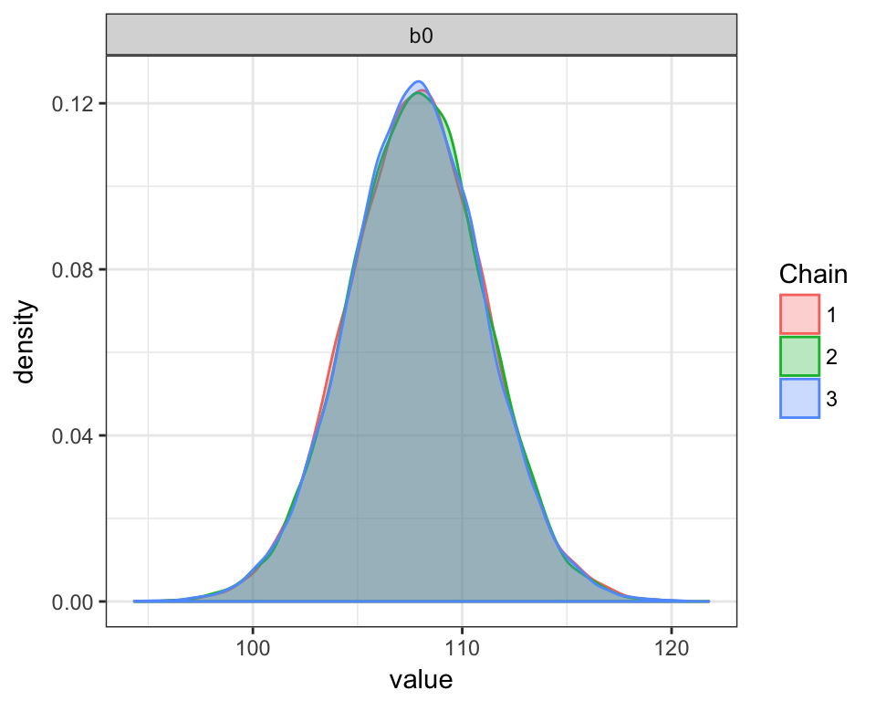

## summary

## generalized linear model

terminology

- \(y\) predicted variable, data, observation, …
- \(X\) predictor variables for \(y\), explanatory variables, …

blueprint of a GLM

\[ \begin{align*} \eta & = \text{linear_combination}(X) \\ \mu & = \text{link_fun}( \ \eta, \theta_{\text{LF}} \ ) \\ y & \sim \text{lh_fun}( \ \mu, \ \theta_{\text{LH}} \ ) \end{align*} \]

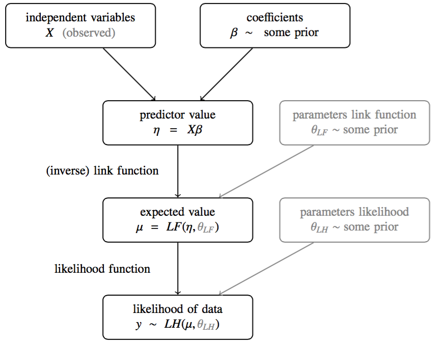

## outlook

Friday

- robust regression
- GLM with nominal predictors
- GLM with nominal & ordinal predicted variables

Tuesday

- mixed effects models
- model comparison by cross-validation